| Caractéristiques du chef de ménage | Refugees N = 14,3441 | Host community North N = 7,4531 |
| --- | --- | --- |
| AgeYears |  |  |
| 00 | 464 (3.2%) | 256 (3.4%) |
| 01 | 468 (3.3%) | 250 (3.4%) |
| 02 | 621 (4.3%) | 230 (3.1%) |
| 03 | 545 (3.8%) | 272 (3.6%) |
| 04 | 543 (3.8%) | 253 (3.4%) |
| 05 | 396 (2.8%) | 144 (1.9%) |
| 06 | 507 (3.5%) | 300 (4.0%) |
| 07 | 436 (3.0%) | 273 (3.7%) |
| 08 | 516 (3.6%) | 281 (3.8%) |
| 09 | 472 (3.3%) | 206 (2.8%) |
| 10 | 445 (3.1%) | 262 (3.5%) |
| 11 | 438 (3.1%) | 153 (2.1%) |
| 12 | 452 (3.2%) | 248 (3.3%) |
| 13 | 468 (3.3%) | 178 (2.4%) |
| 14 | 448 (3.1%) | 173 (2.3%) |
| 15 | 455 (3.2%) | 240 (3.2%) |
| 16 | 344 (2.4%) | 162 (2.2%) |
| 17 | 410 (2.9%) | 170 (2.3%) |
| 18 | 426 (3.0%) | 241 (3.2%) |
| 19 | 331 (2.3%) | 153 (2.1%) |
| 20 | 322 (2.2%) | 223 (3.0%) |
| 21 | 230 (1.6%) | 87 (1.2%) |
| 22 | 256 (1.8%) | 141 (1.9%) |
| 23 | 277 (1.9%) | 123 (1.7%) |
| 24 | 163 (1.1%) | 85 (1.1%) |
| 25 | 205 (1.4%) | 168 (2.3%) |
| 26 | 161 (1.1%) | 72 (1.0%) |
| 27 | 150 (1.0%) | 64 (0.9%) |
| 28 | 166 (1.2%) | 102 (1.4%) |
| 29 | 106 (0.7%) | 64 (0.9%) |
| 30 | 155 (1.1%) | 181 (2.4%) |
| 31 | 128 (0.9%) | 37 (0.5%) |
| 32 | 106 (0.7%) | 51 (0.7%) |
| 33 | 113 (0.8%) | 30 (0.4%) |
| 34 | 86 (0.6%) | 28 (0.4%) |
| 35 | 182 (1.3%) | 140 (1.9%) |
| 36 | 174 (1.2%) | 54 (0.7%) |
| 37 | 114 (0.8%) | 43 (0.6%) |
| 38 | 140 (1.0%) | 88 (1.2%) |
| 39 | 113 (0.8%) | 43 (0.6%) |
| 40 | 145 (1.0%) | 150 (2.0%) |
| 41 | 117 (0.8%) | 18 (0.2%) |
| 42 | 67 (0.5%) | 30 (0.4%) |
| 43 | 101 (0.7%) | 47 (0.6%) |
| 44 | 61 (0.4%) | 22 (0.3%) |
| 45 | 131 (0.9%) | 158 (2.1%) |
| 46 | 120 (0.8%) | 22 (0.3%) |
| 47 | 40 (0.3%) | 21 (0.3%) |
| 48 | 64 (0.4%) | 38 (0.5%) |
| 49 | 52 (0.4%) | 17 (0.2%) |
| 50 | 94 (0.7%) | 150 (2.0%) |
| 51 | 79 (0.6%) | 9 (0.1%) |
| 52 | 25 (0.2%) | 16 (0.2%) |
| 53 | 47 (0.3%) | 20 (0.3%) |
| 54 | 33 (0.2%) | 11 (0.1%) |
| 55 | 40 (0.3%) | 60 (0.8%) |
| 56 | 63 (0.4%) | 18 (0.2%) |
| 57 | 25 (0.2%) | 7 (<0.1%) |
| 58 | 20 (0.1%) | 10 (0.1%) |
| 59 | 33 (0.2%) | 7 (<0.1%) |
| 60 or more | 455 (3.2%) | 353 (4.7%) |
| Sexe |  |  |
| Male | 7,000 (49%) | 3,695 (50%) |
| Female | 7,333 (51%) | 3,757 (50%) |
| Unknown | 11 | 1 |
| Statut matrimonial actuel |  |  |
| monogamous/married | 3,220 (35%) | 2,176 (44%) |
| polygamous/married | 438 (4.7%) | 210 (4.2%) |
| non-formal union | 29 (0.3%) | 8 (0.2%) |
| separated | 207 (2.2%) | 53 (1.1%) |
| divorced | 127 (1.4%) | 30 (0.6%) |
| widow or widower | 256 (2.8%) | 165 (3.3%) |
| never married | 5,016 (54%) | 2,322 (47%) |
| Unknown | 5,051 | 2,489 |

**Répartition par âge**

Les jeunes enfants (0-10 ans) représentent une proportion significative de la population, ce qui indique une forte natalité ou un impact démographique marqué chez les plus jeunes.

À partir de 20 ans, on observe une diminution progressive des effectifs, particulièrement après 40 ans.

La tranche “60 ans et plus” est relativement faible comparée aux groupes plus jeunes, ce qui peut refléter des enjeux liés à l’espérance de vie ou aux conditions de vie difficiles.

**Répartition par sexe**

La distribution du sexe est presque équilibrée avec environ 49-51% dans les deux groupes.

Cette parité peut indiquer une structure démographique stable sans déséquilibre majeur.

**Statut matrimonial**

Les réfugiés :

Une forte proportion n’a jamais été mariée (54%).

Le mariage monogame est dominant (35%), suivi du mariage polygame (4.7%).

Une minorité est divorcée, séparée ou veuve.

Communauté d’accueil :

Une proportion plus élevée est mariée monogame (44% contre 35% chez les réfugiés).

Les personnes veuves et divorcées ont des proportions comparables.

Le taux de célibat est un peu moins élevé (47% contre 54% chez les réfugiés).

Interprétation globale Dynamique démographique : La répartition par âge montre une population relativement jeune, ce qui peut avoir des implications sur les besoins en éducation, emploi et santé.

Comparaison entre groupes : La communauté hôte semble avoir une proportion légèrement plus élevée de personnes mariées que les réfugiés, ce qui peut refléter des différences culturelles ou des impacts liés à l’instabilité du déplacement.

Implication politique et sociale : Ces résultats peuvent guider les interventions en matière d’intégration sociale, logement et santé, notamment pour les réfugiés où le célibat est plus fréquent.

## 2.3 Crowding Index ou l’indice d’affluence

**Nombre d’individu par ménage**

```
   Min. 1st Qu.  Median    Mean 3rd Qu.    Max.
  1.000   5.000   7.000   7.128   9.000  17.000
```

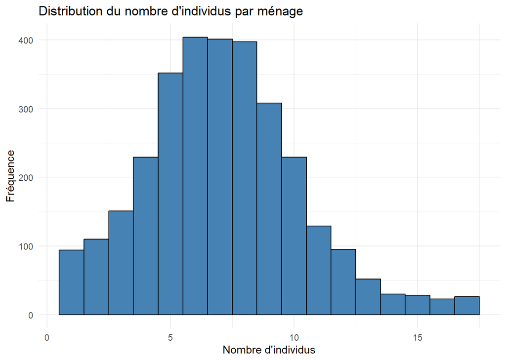

Analyse de la distribution

Tendance observée :

La distribution est asymétrique et orientée vers la droite, ce qui montre qu’il existe quelques ménages très peuplés mais qu’ils sont rares.

Conditions de logement : Des ménages plus grands peuvent faire face à des défis en termes d’espace de vie et de confort.

Implications socio-économiques : Les ménages nombreux nécessitent davantage de ressources, ce qui pourrait influencer les politiques de logement et d’aide sociale.

```
   Min. 1st Qu.  Median    Mean 3rd Qu.    Max.    NA's
  1.000   2.000   2.000   2.388   3.000  21.000       6
```

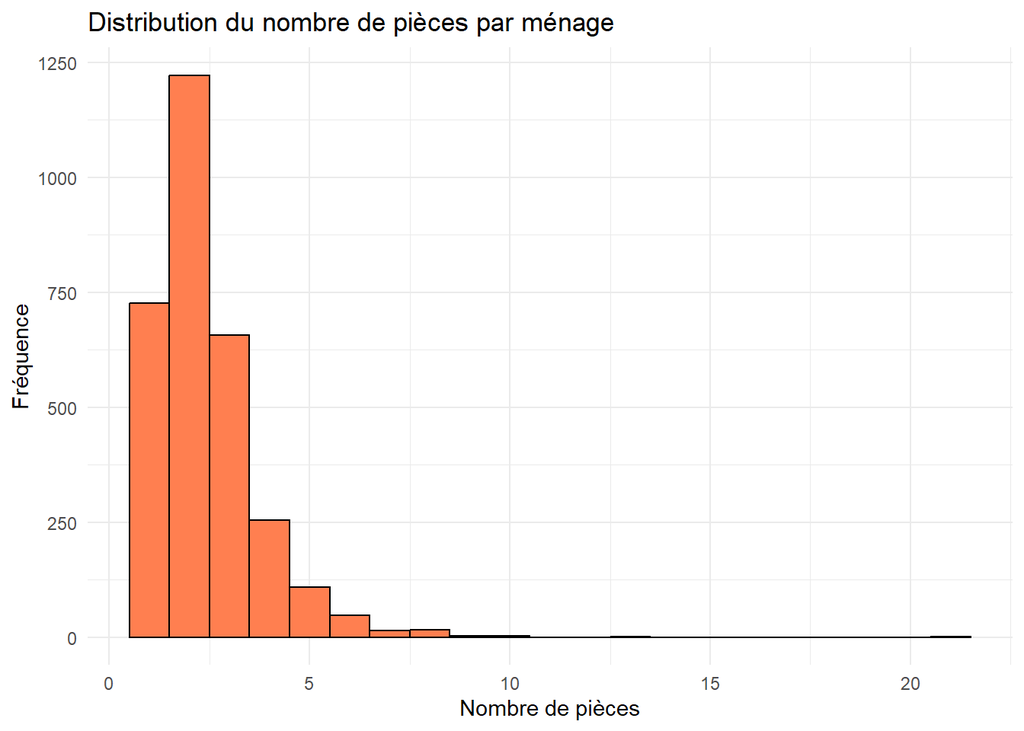

Surpeuplement possible : Certains ménages très peuplés existent, ce qui pourrait être un indicateur de conditions de logement précaires ou de forte dépendance économique.

Implications sociales et économiques Les ménages plus grands nécessitent plus de ressources, ce qui peut influencer les politiques sociales et d’aide aux réfugiés.

Une répartition de ce type peut informer les décisions de logement, en identifiant les besoins en termes d’espace et d’aménagement familial.

**Calcul de l’indice d’affluence (Crowding Index)**

```
   Min. 1st Qu.  Median    Mean 3rd Qu.    Max.    NA's
 0.1429  2.0000  3.0000  3.5548  4.5000 15.0000       6
```

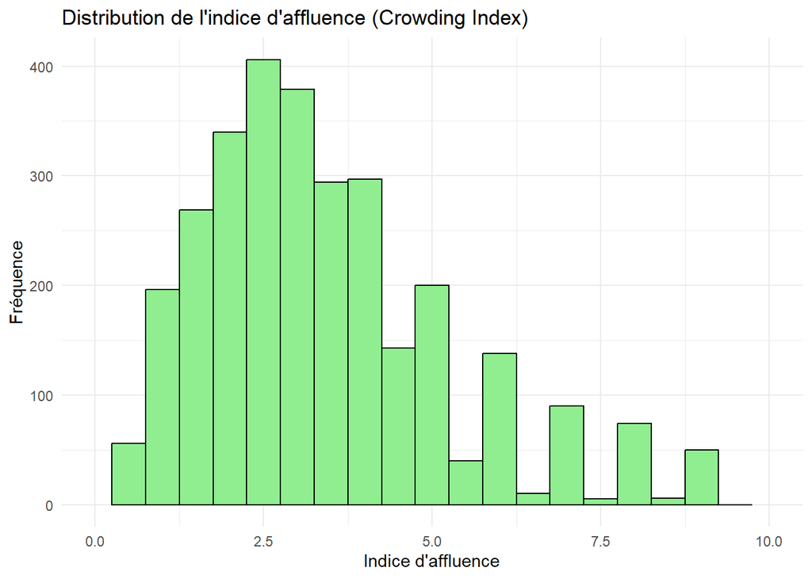

**Forme de la distribution** : L’histogramme est asymétrique et orienté vers la droite, ce qui signifie que les ménages plus nombreux existent, mais sont moins fréquents.

Surpeuplement potentiel : La présence de ménages de grande taille peut poser des problèmes en matière de logement et d’accès aux ressources.

Différences entre populations : Si l’on compare réfugiés et communauté hôte, les réfugiés pourraient avoir des ménages plus grands en raison de regroupements familiaux.

**Implications socio-économiques** Logement et confort de vie : Ces résultats peuvent aider à planifier les politiques de construction et d’aménagement.

Économie domestique : Les ménages nombreux peuvent être plus vulnérables économiquement et nécessiter des stratégies de survie différentes.

Intervention sociale : Une forte densité dans certains foyers pourrait être un indicateur de besoins accrus en assistance sociale et sanitaire.

**Proportion de crowding dans les ménages**

```
# A tibble: 5 × 3
  categorie_crowding     n proportion
  <chr>              <int>      <dbl>
1 1 - 2                476     15.6
2 2 - 3                737     24.1
3 < 1                   68      2.22
4 >= 3                1771     57.9
5 <NA>                   6      0.196
```

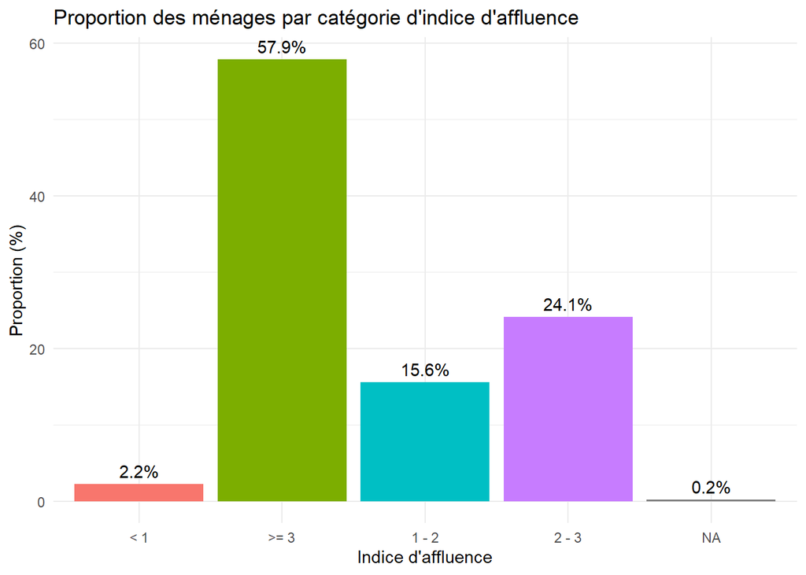

**Analyse** Majorité des ménages ont un indice >= 3 (57.9%) : Cela signifie que plus de la moitié des ménages vivent dans des conditions de forte densité, où chaque pièce est occupée par plusieurs individus.

24.1% des ménages sont entre 2 - 3 : Ces ménages sont également densément peuplés, mais avec une meilleure répartition que ceux ayant un indice supérieur à 3.

15.6% ont un indice 1 - 2 : Indique une répartition modérée de l’espace.

Seulement 2.2% des ménages ont un indice <1, ce qui signifie que ces ménages disposent d’un espace relativement confortable.

0.2% des valeurs sont manquantes (NA), ce qui peut être dû à des données incomplètes ou des erreurs de saisie.

**Implications** Conditions de vie précaires : La majorité des ménages vivent dans des espaces surpeuplés (>= 3), ce qui peut engendrer des problèmes de santé, de confort et de qualité de vie.

Besoin d’intervention : Les ménages avec un indice élevé peuvent nécessiter des mesures pour améliorer leurs conditions de logement.

```
Labels pour la variable groupe de population:
            Refugees       Asylum-seekers Host community North
                   1                    2                    3
           Returnees
                   4
```

```
# A tibble: 2 × 7
  intro_07_1                   n moyenne mediane ecart_type   min   max
  <dbl+lbl>                <int>   <dbl>   <dbl>      <dbl> <dbl> <dbl>
1 1 [Refugees]              2068    3.40    3          1.97 0.143    15
2 3 [Host community North]   990    3.88    3.22       2.29 0.333    14
```

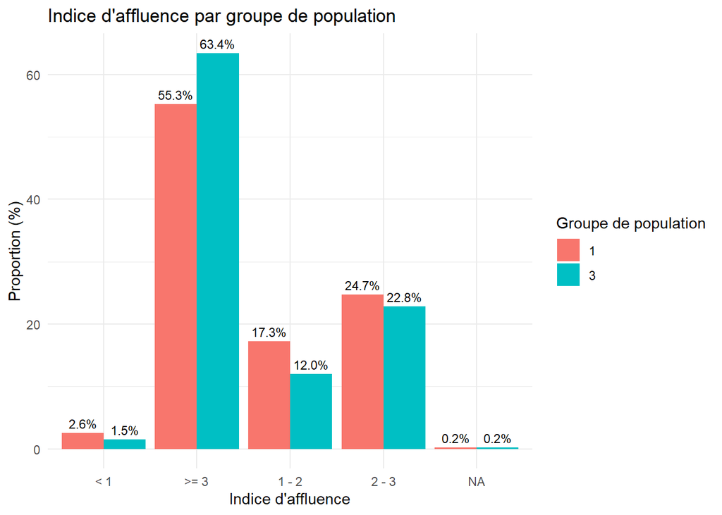

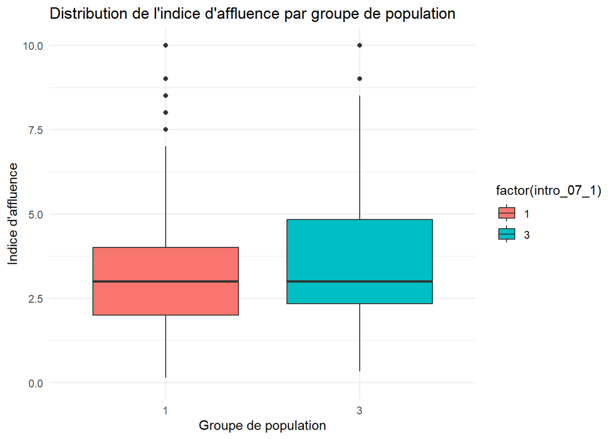

Analyse des proportions Catégorie < 1 (faible densité) :

Groupe 1 : 2.6%

Groupe 3 : 1.5% → Très peu de ménages bénéficient d’un espace confortable.

Catégorie >= 3 (forte densité) :

Groupe 1 : 55.3%

Groupe 3 : 63.4% → La majorité des ménages vivent dans des espaces surpeuplés.

Catégorie 1 - 2 (densité modérée) :

Groupe 1 : 17.3%

Groupe 3 : 12.0% → Quelques ménages ont une occupation raisonnable par pièce.

Catégorie 2 - 3 (densité élevée) :

Groupe 1 : 24.7%

Groupe 3 : 22.8% → Une part importante des ménages ont un taux d’affluence élevé.

Valeurs NA (non renseignées) : 0.2% → Indicateur de données manquantes ou de ménages atypiques.

**Interprétation des tendances** Surpeuplement majoritaire : Plus de 50% des ménages ont un indice ≥ 3, indiquant des conditions de vie précaires et un manque d’espace.

Différences entre les groupes :

Le Groupe 3 a une densité encore plus élevée (63.4% contre 55.3%), ce qui pourrait indiquer une vulnérabilité accrue ou des disparités socio-économiques.

Groupe 1 a une meilleure répartition avec plus de ménages dans la catégorie 1 - 2, suggérant un meilleur accès au logement.

**Implications socio-économiques**

Les familles vivant dans des ménages très peuplés peuvent être plus vulnérables aux problèmes de santé et aux tensions sociales.

Un manque d’espace peut affecter la qualité de vie, l’éducation des enfants, et l’accès aux ressources essentielles.

**Perspectives d’intervention** Amélioration du logement : Mise en place de programmes pour réduire la densité des ménages surpeuplés. Approches ciblées : Les interventions pourraient être adaptées selon la population et le niveau de surpeuplement. Surveillance démographique : Ce type de données est crucial pour la planification des infrastructures et des services sociaux.

**Analyse des statistiques descriptives** Groupe 1 (Rouge) :

La médiane de l’indice d’affluence est autour de 3.

Les valeurs varient de 0 à environ 8, avec quelques outliers au-delà de 8.

La boîte est relativement compacte, indiquant une faible dispersion autour de la médiane.

Groupe 3 (Bleu) :

La médiane est légèrement plus élevée que celle du Groupe 1.

Une plus grande dispersion est observée.

Des valeurs aberrantes (outliers) sont présentes au-dessus de 8, montrant quelques ménages très surpeuplés.

**Interprétation des tendances** Surpeuplement plus marqué dans le Groupe 3 : La médiane et la dispersion plus élevée suggèrent que ces ménages ont une densité d’affluence plus importante.

Espacement plus homogène dans le Groupe 1 : La distribution plus compacte pourrait indiquer des logements mieux structurés.

Outliers : Ces points extrêmes représentent des ménages où l’espace de vie est particulièrement insuffisant, pouvant impacter le bien-être, la santé et la qualité de vie.

**Implications socio-économiques** Conditions de logement : Des indices d’affluence élevés peuvent être associés à des conditions de vie précaires, notamment en termes de confort et d’hygiène. Besoins en politiques d’habitat : Une intervention peut être nécessaire pour réduire la surpopulation et améliorer l’accès aux logements décents. Impact sur la santé et l’éducation : Un espace trop restreint peut affecter le développement des enfants et l’accès à une bonne alimentation et hygiène.

# Analyse de la sécurité alimentaire des déplacés internes

## 2.4 Score de Consommation Alimentaire (SCA)

Le Score de Consommation Alimentaire (SCA) est un indicateur proxy développé par le Programme Alimentaire Mondial pour mesurer la sécurité alimentaire des ménages. C’est un score composite basé sur la diversité alimentaire, la fréquence de consommation et l’importance nutritionnelle relative des groupes d’aliments consommés.

###### 2.4.0.0.0.1 Analyse descriptive des variables composant le SCA

```
Table: Statistiques descriptives des variables du SCA

|variable        |   moyenne| mediane|     type| min| max| valides| manquants|
|:---------------|---------:|-------:|--------:|---:|---:|-------:|---------:|
|food_div1       | 3.2213491|       3|       NA|   0|   7|      NA|        NA|
|food_div1_ecart |        NA|      NA| 2.640259|  NA|  NA|      NA|        NA|
|food_div1_n     |        NA|      NA|       NA|  NA|  NA|    3054|         4|
|food_div2       | 1.1100917|       0|       NA|   0|   7|      NA|        NA|
|food_div2_ecart |        NA|      NA| 1.843696|  NA|  NA|      NA|        NA|
|food_div2_n     |        NA|      NA|       NA|  NA|  NA|    3052|         6|
|food_div3       | 0.5188463|       0|       NA|   0|   7|      NA|        NA|
|food_div3_ecart |        NA|      NA| 1.404870|  NA|  NA|      NA|        NA|
|food_div3_n     |        NA|      NA|       NA|  NA|  NA|    3051|         7|
|food_div4       | 0.6148294|       0|       NA|   0|   7|      NA|        NA|
|food_div4_ecart |        NA|      NA| 1.280462|  NA|  NA|      NA|        NA|
|food_div4_n     |        NA|      NA|       NA|  NA|  NA|    3048|        10|
|food_div5       | 0.9244167|       0|       NA|   0|   7|      NA|        NA|
|food_div5_ecart |        NA|      NA| 1.746097|  NA|  NA|      NA|        NA|
|food_div5_n     |        NA|      NA|       NA|  NA|  NA|    3043|        15|
|food_div6       | 0.2994740|       0|       NA|   0|   7|      NA|        NA|
|food_div6_ecart |        NA|      NA| 1.139148|  NA|  NA|      NA|        NA|
|food_div6_n     |        NA|      NA|       NA|  NA|  NA|    3042|        16|
|food_div7       | 1.0223170|       0|       NA|   0|   7|      NA|        NA|
|food_div7_ecart |        NA|      NA| 1.907796|  NA|  NA|      NA|        NA|
|food_div7_n     |        NA|      NA|       NA|  NA|  NA|    3047|        11|
|food_div8       | 0.8103222|       0|       NA|   0|   7|      NA|        NA|
|food_div8_ecart |        NA|      NA| 1.739492|  NA|  NA|      NA|        NA|
|food_div8_n     |        NA|      NA|       NA|  NA|  NA|    3042|        16|
```

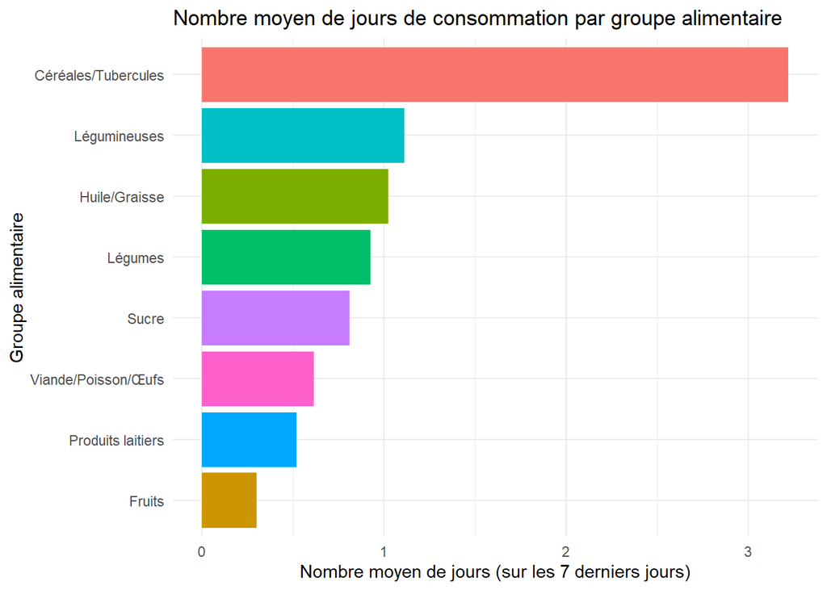

**Analyse des tendances** Le groupe alimentaire “food_div1” est le plus consommé, avec environ 3 jours en moyenne.

Les autres groupes alimentaires (food_div2 à food_div8) ont des fréquences de consommation inférieures à 2 jours, voire proches de 1 jour pour certains.

Différences entre groupes :

Certains aliments semblent être plus essentiels ou plus accessibles, tandis que d’autres sont consommés plus rarement.

Une variabilité importante entre les groupes alimentaires reflète des habitudes alimentaires différentes.

**Interprétation des résultats** Alimentation de base : Le groupe “food_div1”, ayant la fréquence la plus élevée, représente les aliments les plus courants et essentiels dans le régime des ménages.

Régime peu diversifié : La faible consommation des autres groupes suggère que l’accès à certains types d’aliments pourrait être limité, influençant la diversité nutritionnelle.

Sécurité alimentaire :

Si certains groupes alimentaires sont consommés moins d’une fois par semaine, cela pourrait indiquer une insécurité alimentaire ou un manque d’accès à une alimentation équilibrée.

La forte consommation d’un seul groupe alimentaire peut montrer une dépendance à certains produits et un risque de déséquilibre nutritionnel.

**Implications pour l’analyse socio-économique** Impact sur la santé : Une faible diversité alimentaire peut entraîner des carences nutritionnelles. Nécessité de programmes alimentaires : Encourager une meilleure diversité pour garantir un équilibre nutritionnel. Facteurs économiques : L’accès à certains groupes alimentaires dépend peut-être de facteurs financiers ou logistiques.

###### 2.4.0.0.0.2 Calcul du Score de Consommation Alimentaire

```
Table: Poids attribués aux groupes alimentaires pour le calcul du SCA

|groupe_alimentaire  |variable  | poids|
|:-------------------|:---------|-----:|
|Céréales/Tubercules |food_div1 |   2.0|
|Légumineuses        |food_div2 |   3.0|
|Produits laitiers   |food_div3 |   4.0|
|Viande/Poisson/Œufs |food_div4 |   4.0|
|Légumes             |food_div5 |   1.0|
|Fruits              |food_div6 |   1.0|
|Huile/Graisse       |food_div7 |   0.5|
|Sucre               |food_div8 |   0.5|
```

```
   Min. 1st Qu.  Median    Mean 3rd Qu.    Max.    NA's
   0.00    6.00   14.00   16.46   23.00  107.00      23
```

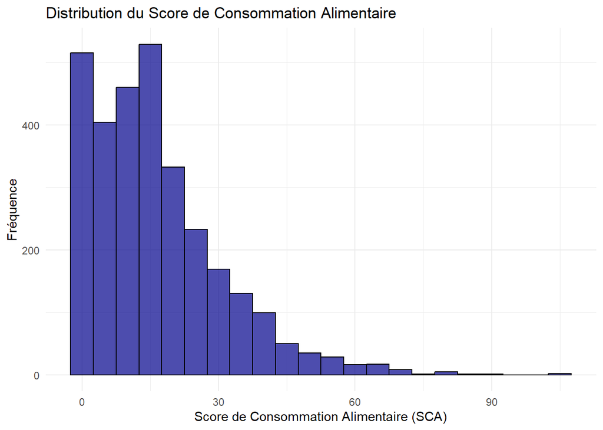

**Observations clés**

La majorité des scores sont concentrés entre 0 et 30.

Plus le score augmente, moins les ménages sont nombreux, indiquant une faible diversité alimentaire dans une large proportion de la population.

**Interprétation des tendances**

Sécurité alimentaire précaire : Un grand nombre de ménages ont un SCA très bas (0-10), ce qui peut indiquer une insécurité alimentaire sévère.

Accès limité à une alimentation diversifiée : La diminution progressive des scores suggère que très peu de ménages atteignent un niveau de sécurité alimentaire acceptable.

Impact potentiel du déplacement forcé : Les populations étudiées, en particulier les réfugiés, peuvent être touchées par un manque d’accès à une alimentation variée, ce qui nécessite une intervention humanitaire.

**Implications pour l’analyse socio-économique**

Santé et nutrition : Une alimentation peu diversifiée peut entraîner des carences nutritionnelles et des problèmes de santé à long terme. Politiques d’aide alimentaire : Ces résultats peuvent aider à adapter les programmes de distribution alimentaire pour améliorer la sécurité nutritionnelle. Évaluation des risques : Les ménages avec un SCA faible doivent être prioritaires pour l’aide humanitaire et les interventions socio-économiques.

###### 2.4.0.0.0.3 Catégorisation du SCA selon différents seuils

```
Table: Répartition des ménages selon les seuils SCA 21/35

|categorie_sca_21_35 |    n| proportion|
|:-------------------|----:|----------:|
|Acceptable          |  311| 10.1700458|
|Limite              |  626| 20.4708960|
|Pauvre              | 2098| 68.6069326|
|NA                  |   23|  0.7521256|
```

```
Table: Répartition des ménages selon les seuils SCA 28/42

|categorie_sca_28_42 |    n| proportion|
|:-------------------|----:|----------:|
|Acceptable          |  169|  5.5264879|
|Limite              |  393| 12.8515370|
|Pauvre              | 2473| 80.8698496|
|NA                  |   23|  0.7521256|
```

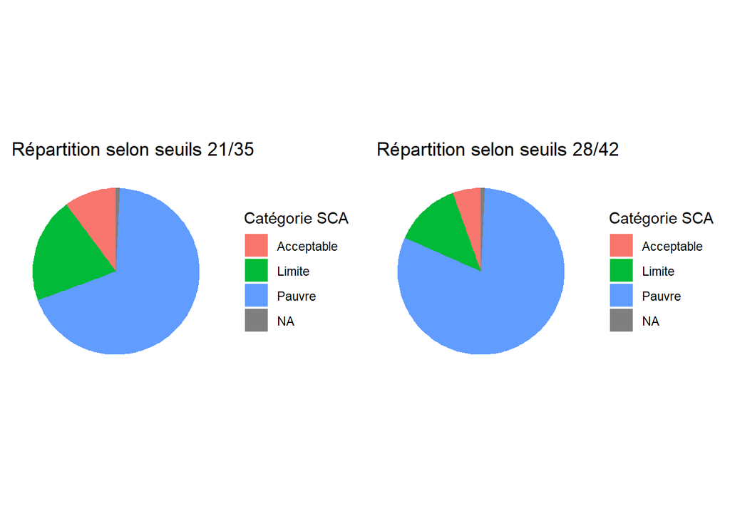

La proportion de NA (non renseigné) reste stable dans les deux seuils.

Catégorie Pauvre significative : Une part importante de la population reste en situation de forte insécurité alimentaire, même avec un seuil plus souple.

Limites de l’évaluation : L’impact du seuil montre que les résultats doivent être analysés avec précaution pour éviter des conclusions optimistes ou alarmistes biaisées.

**Implications socio-économiques** Évaluation des seuils à adapter : Choisir des seuils pertinents pour l’analyse des besoins en aide alimentaire. Mesures prioritaires : La population classée “Pauvre” nécessite une intervention urgente. Surveillance continue : Suivi des données NA pour éviter un biais statistique dans l’analyse globale.

###### 2.4.0.0.0.4 Représentation spatiale du SCA par région et département

```
Labels pour admin1 (Région):
            Unity        Upper Nile Central Equatoria           Jonglei
                1                 2                 3                 4
Western Equatoria Eastern Equatoria
                5                 6
```

```
Labels pour admin2 (Département):
 Pariang    Maban     Juba   Morobo      Yei Pochalla      Ezo   Maridi
       1        2        3        4        5        6        7        8
 Tambura   Yambio    Magwi     Juba
       9       10       11       12
```

```
Table: Score de Consommation Alimentaire par région

| admin1| sca_moyen| sca_median|    n| pct_pauvre_21_35| pct_limite_21_35| pct_acceptable_21_35|
|------:|---------:|----------:|----:|----------------:|----------------:|--------------------:|
|      1|      16.8|       14.0| 1064|             69.9|             22.6|                  7.5|
|      2|      14.5|       10.2| 1466|             74.5|             15.1|                 10.5|
|      3|      27.3|       25.0|  114|             34.5|             36.3|                 29.2|
|      4|       8.0|        7.0|   35|             96.4|              3.6|                  0.0|
|      5|      21.4|       20.5|  285|             50.2|             36.8|                 13.0|
|     NA|      18.0|       14.5|   94|             68.5|             21.7|                  9.8|
```

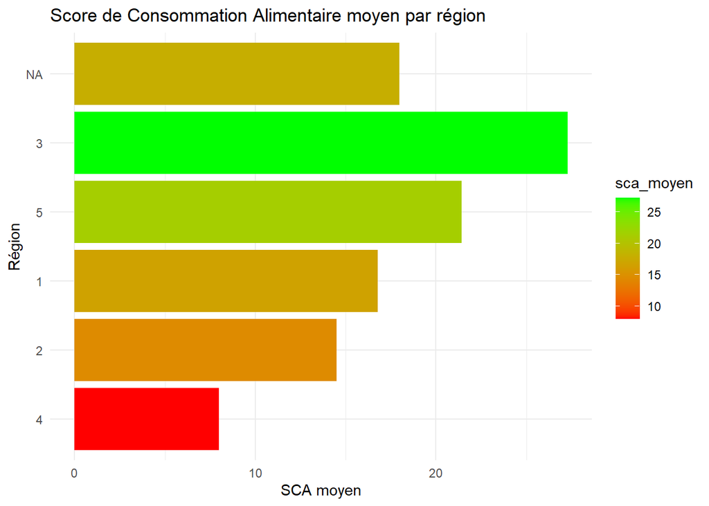

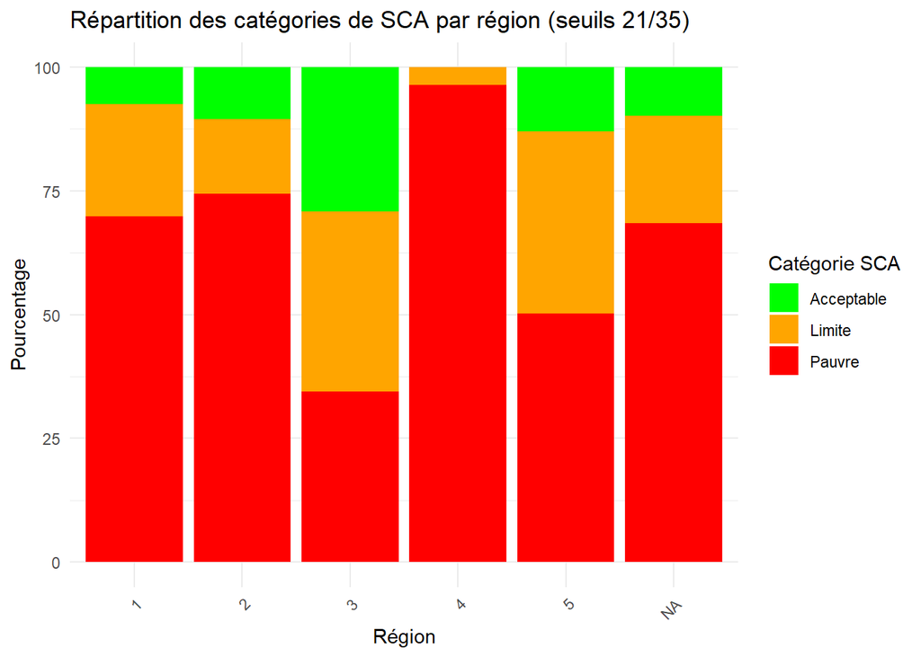

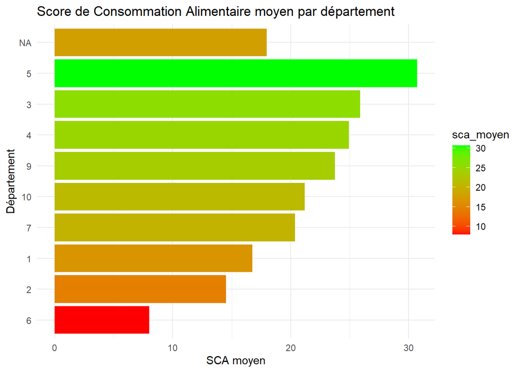

Région 2 est également en situation préoccupante (~15).

Région 3 affiche le score le plus élevé (~27) → Meilleure diversité alimentaire.

*Interprétation des tendances* Régions vulnérables : Les scores faibles en Région 4 et 2 pourraient être liés à des problèmes d’accès à la nourriture, des tensions économiques ou une insécurité alimentaire accrue.

Disparités régionales : La différence entre Région 3 et Région 4 montre une inégalité d’accès à une alimentation diversifiée.

Influence des facteurs socio-économiques : Les variations du SCA peuvent être liées à des éléments comme l’accès aux marchés, l’aide humanitaire ou la capacité des ménages à obtenir des aliments variés.

*Implications pour l’analyse socio-économique* Intervention ciblée : Les régions avec un SCA faible doivent être prioritaires pour les programmes de sécurité alimentaire. Politiques de distribution : Une analyse approfondie permettrait de réajuster l’aide alimentaire selon les besoins spécifiques de chaque région. Suivi des tendances : Si ces écarts se creusent, cela pourrait signaler une dégradation de la situation alimentaire dans certaines zones.

**Catégorie de SCA par région**

*Analyse des proportions régionales*

La plupart des régions ont une grande proportion de ménages en insécurité alimentaire (Pauvre en rouge).

Région 3 présente la répartition la plus équilibrée, avec une proportion plus élevée d’Acceptable.

Région 1 et 4 sont fortement touchées par l’insécurité alimentaire, avec une dominance de la catégorie “Pauvre”.

La catégorie NA regroupe les ménages pour lesquels les données sont incomplètes.

*Interprétation des tendances*

Disparités régionales marquées : Certaines régions ont une meilleure accessibilité alimentaire alors que d’autres connaissent des restrictions sévères.

Impact socio-économique : Une forte proportion de ménages en catégorie “Pauvre” peut indiquer des problèmes d’accès aux aliments, une instabilité économique ou un manque d’infrastructures alimentaires.

Influence des politiques locales : Les régions avec une meilleure répartition (ex. Région 3) pourraient bénéficier d’une meilleure distribution des ressources alimentaires ou de programmes d’aide efficaces.

*Implications et recommandations*

Intervention ciblée : Les régions avec un SCA majoritairement “Pauvre” nécessitent une priorité en aide alimentaire. Programmes nutritionnels : Améliorer l’éducation alimentaire et la diversification des sources alimentaires. Surveillance des zones critiques : Suivi régulier des régions en insécurité alimentaire pour éviter une aggravation.

**SCA moyen par département

*Analyse des tendances*

Les départements sont numérotés (NA, 5, 3, 4, 9, 10, 7, 1, 2, 6), avec leur score moyen de consommation alimentaire représenté par des barres horizontales.

Les couleurs varient du rouge (SCA faible) au vert (SCA élevé), facilitant la lecture des différences entre les départements.

Le département “5” possède le score le plus élevé, tandis que le département “6” a le score le plus bas.

*Interprétation des résultats*

Disparités alimentaires régionales : Certains départements ont un SCA élevé, indiquant une meilleure diversité alimentaire et un accès plus stable à la nourriture. À l’inverse, d’autres ont un score très faible, signalant des risques accrus d’insécurité alimentaire.

Risque de malnutrition : Les départements avec un SCA autour de 10-15 pourraient être en situation critique, nécessitant des interventions en matière de sécurité alimentaire.

Influences possibles :

Facteurs économiques : Le pouvoir d’achat des ménages peut affecter leur accès à une alimentation variée.

Disponibilité des ressources alimentaires : Certaines régions ont peut-être moins d’accès aux marchés ou à l’aide humanitaire.

Conditions climatiques : Des sécheresses ou inondations peuvent influencer la production et l’approvisionnement alimentaire.

*Implications socio-économiques*

Planification des interventions alimentaires : Les départements avec des scores très bas devraient être prioritaires pour des programmes de soutien. Études complémentaires : Il serait pertinent d’analyser les groupes alimentaires consommés dans chaque département pour identifier les carences spécifiques. Suivi et adaptation : Mettre en place un système de surveillance de la sécurité alimentaire pour ajuster les politiques en fonction des évolutions locales.

### 2.4.1 Analyse du SCA selon le statut de déplacement

```
Table: Score de Consommation Alimentaire par statut de déplacement

|intro_07_1           | sca_moyen| sca_median| sca_ecart_type|    n| pct_pauvre_21_35| pct_limite_21_35| pct_acceptable_21_35|
|:--------------------|---------:|----------:|--------------:|----:|----------------:|----------------:|--------------------:|
|Refugees             |      16.4|         14|           14.2| 2068|             67.5|             22.5|                 10.0|
|Host community North |      16.6|         14|           14.6|  990|             72.4|             16.8|                 10.8|
```

```
Test ANOVA pour comparer les moyennes du SCA entre les groupes:
              Df Sum Sq Mean Sq F value Pr(>F)
intro_07_1     1     19   18.53   0.091  0.764
Residuals   3033 620829  204.69
23 observations effacées parce que manquantes
```

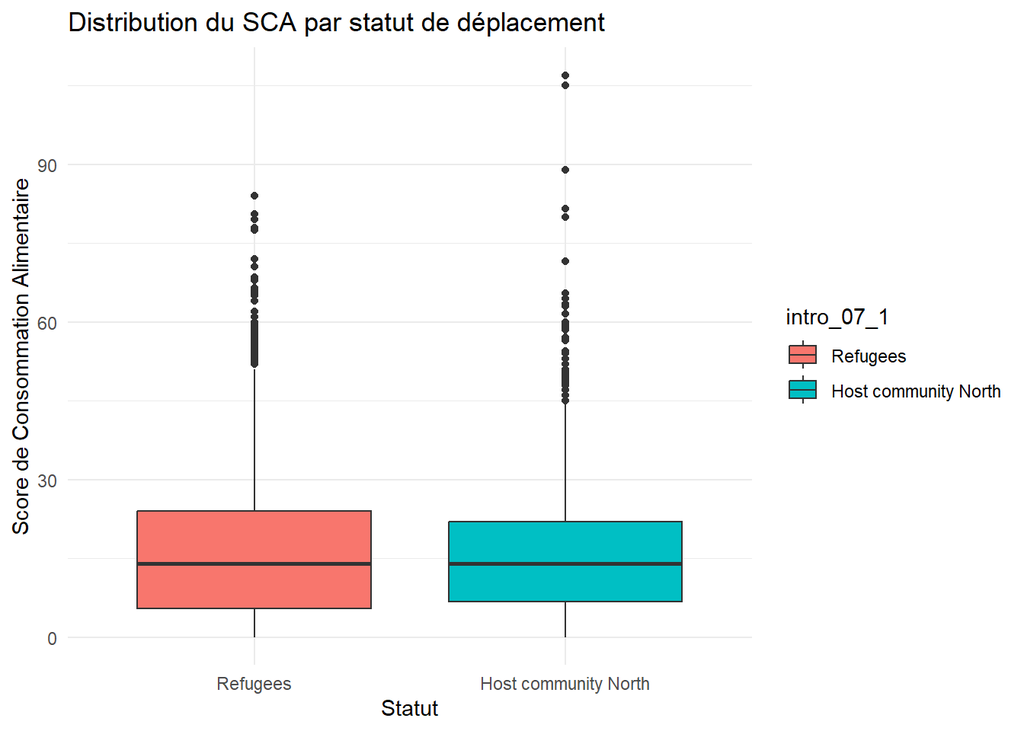

[figure not shown]

**Distribution SCA par statut de déplacement**

Deux catégories de statut de déplacement :

Présence d’outliers :

**Répartition SCA par statut de déplacement** *Analyse de la répartition des catégories de SCA*

Catégorie “Pauvre” (Rouge) domine largement dans les deux statuts. Catégorie “Limite” (Orange) est présente, mais représente une proportion plus faible. Catégorie “Acceptable” (Vert) est minoritaire, montrant que très peu de ménages ont une sécurité alimentaire satisfaisante.

La majorité des ménages sont en insécurité alimentaire (“Pauvre”), ce qui suggère des conditions difficiles pour l’ensemble de la population étudiée.

Le statut de déplacement n’affecte pas significativement la répartition des scores, ce qui pourrait indiquer que les conditions alimentaires restent précaires indépendamment du statut.

*Interprétation des tendances*

Insécurité alimentaire élevée : La forte proportion de ménages classés dans la catégorie “Pauvre” montre une situation préoccupante nécessitant une intervention ciblée.

Risque de malnutrition : Une faible diversité alimentaire peut entraîner des carences nutritionnelles, affectant la santé des populations déplacées.

*Implications socio-économiques et recommandations*

Programmes d’aide alimentaire adaptés : Renforcer l’accès à une alimentation variée et équilibrée. Interventions ciblées : Identifier les sous-groupes les plus vulnérables pour une meilleure distribution de l’aide. Suivi des tendances alimentaires : Collecter plus de données pour analyser les évolutions du SCA et mesurer l’impact des politiques de soutien.

###### 2.4.1.0.0.1 L’indice réduit des stratégies de survie (rCSI)

L’indice réduit des stratégies de survie (rCSI) est un indicateur qui mesure les comportements d’adaptation que les ménages adoptent lorsqu’ils n’ont pas accès à suffisamment de nourriture. Il est basé sur un ensemble de cinq stratégies de survie communes liées à la consommation alimentaire. Un score plus élevé indique une plus grande insécurité alimentaire.

###### 2.4.1.0.0.2 Analyse descriptive des variables qui composent le rCSI

Les cinq stratégies d’adaptation communes utilisées pour calculer le rCSI sont:

1. Consommer des aliments moins préférés et moins chers (Food02a)
2. Emprunter de la nourriture ou compter sur l’aide de proches (Food05a)
3. Limiter la taille des portions au moment des repas (Food06a)
4. Réduire le nombre de repas par jour (Food08a)
5. Réduire la consommation des adultes pour nourrir les enfants (Food07a)

```
tibble [3,058 × 5] (S3: tbl_df/tbl/data.frame)
 $ food02a: dbl+lbl [1:3058] 1, 2, 1, 1, 1, 1, 1, 1, 1, 1, 1, 1, 1, 1, 1, 1, 1, 1,...
   ..@ label       : chr "A member ate less preferred food and less expensive food [Past 30/7 days]"
   ..@ format.stata: chr "%10.0g"
   ..@ labels      : Named num [1:2] 1 2
   .. ..- attr(*, "names")= chr [1:2] "yes" "no"
 $ food05a: dbl+lbl [1:3058] 1, 2, 2, 1, 2, 2, 1, 1, 2, 2, 2, 1, 1, 1, 1, 1, 2, 2,...
   ..@ label       : chr "Any member borrowed food/relied on help to get more food...[Past 30/7 days]"
   ..@ format.stata: chr "%10.0g"
   ..@ labels      : Named num [1:2] 1 2
   .. ..- attr(*, "names")= chr [1:2] "yes" "no"
 $ food06a: dbl+lbl [1:3058] 1, 2, 1, 1, 1, 1, 1, 1, 2, 2, 1, 1, 1, 1, 1, 1, 1, 1,...
   ..@ label       : chr "Any member ate a smaller meal than you felt you needed [Past 30/7 days]"
   ..@ format.stata: chr "%10.0g"
   ..@ labels      : Named num [1:2] 1 2
   .. ..- attr(*, "names")= chr [1:2] "yes" "no"
 $ food08a: dbl+lbl [1:3058] 1, 2, 1, 1, 1, 1, 1, 1, 1, 2, 1, 1, 1, 1, 1, 1, 1, 1,...
   ..@ label       : chr "Any member ate fewer meals in a day [Past 30/7 days]"
   ..@ format.stata: chr "%10.0g"
   ..@ labels      : Named num [1:2] 1 2
   .. ..- attr(*, "names")= chr [1:2] "yes" "no"
 $ food07a: dbl+lbl [1:3058] 1, 2, 1, 1, 1, 1, 2, 2, 1, 2, 1, 1, 1, 1, 1, 1, 2, 1,...
   ..@ label       : chr "Adults ate less to have more food for children under 5? [Past 30/7 days]"
   ..@ format.stata: chr "%10.0g"
   ..@ labels      : Named num [1:2] 1 2
   .. ..- attr(*, "names")= chr [1:2] "yes" "no"
NULL
```

```
Variable: food02a

   1    2 <NA>
2493  563    2

Variable: food05a

   1    2 <NA>
1831 1222    5

Variable: food06a

   1    2 <NA>
2600  454    4

Variable: food08a

   1    2 <NA>
2547  510    1

Variable: food07a

   1    2 <NA>
2145  906    7
```

```
Table: Statistiques descriptives des variables du rCSI

|variable    |        oui| non| manquants|
|:-----------|----------:|---:|---------:|
|food02a_n   | 2493.00000|   0|         2|
|food02a_pct |   81.57723|  NA|        NA|
|food05a_n   | 1831.00000|   0|         5|
|food05a_pct |   59.97380|  NA|        NA|
|food06a_n   | 2600.00000|   0|         4|
|food06a_pct |   85.13425|  NA|        NA|
|food08a_n   | 2547.00000|   0|         1|
|food08a_pct |   83.31698|  NA|        NA|
|food07a_n   | 2145.00000|   0|         7|
|food07a_pct |   70.30482|  NA|        NA|
```

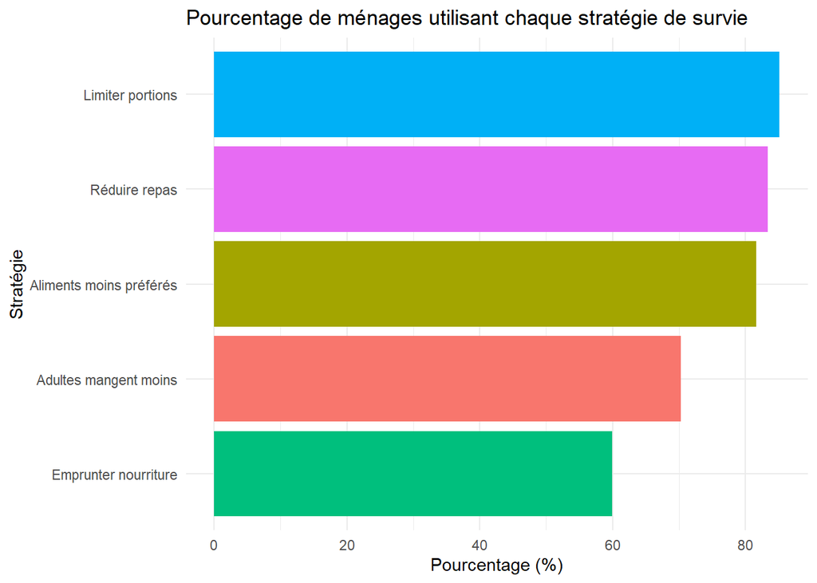

**Interprétation des tendances** Prévalence élevée des stratégies alimentaires : Les ménages adoptent différentes approches pour gérer leur consommation, certaines étant plus populaires.

Les stratégies les plus courantes (food06a et food08a) pourraient être les plus accessibles ou adaptées aux contraintes locales.

Différences d’adoption : food05a, moins utilisée, pourrait être une option plus coûteuse ou moins efficace dans certains contextes.

**Implications socio-économiques**

Comprendre les comportements alimentaires : Identifier quelles stratégies sont essentielles pour les ménages. Intervention ciblée : Si certaines stratégies sont trop dépendantes de ressources extérieures, ajuster les programmes d’aide alimentaire. Amélioration des politiques nutritionnelles : Encourager des alternatives qui permettent une meilleure résilience alimentaire.

###### 2.4.1.0.0.3 Création et analyse de nouvelles variables numériques pour le rCSI

```
Table: Statistiques descriptives des nouvelles variables numériques du rCSI

|variable          |  moyenne| mediane|     type| min| max|
|:-----------------|--------:|-------:|--------:|---:|---:|
|food02a_num       | 3.267997|       3|       NA|   0|   7|
|food02a_num_ecart |       NA|      NA| 2.388702|  NA|  NA|
|food05a_num       | 2.334753|       2|       NA|   0|   7|
|food05a_num_ecart |       NA|      NA| 2.446136|  NA|  NA|
|food06a_num       | 3.442698|       3|       NA|   0|   7|
|food06a_num_ecart |       NA|      NA| 2.348695|  NA|  NA|
|food08a_num       | 3.283611|       3|       NA|   0|   7|
|food08a_num_ecart |       NA|      NA| 2.360722|  NA|  NA|
|food07a_num       | 2.798099|       2|       NA|   0|   7|
|food07a_num_ecart |       NA|      NA| 2.479796|  NA|  NA|
```

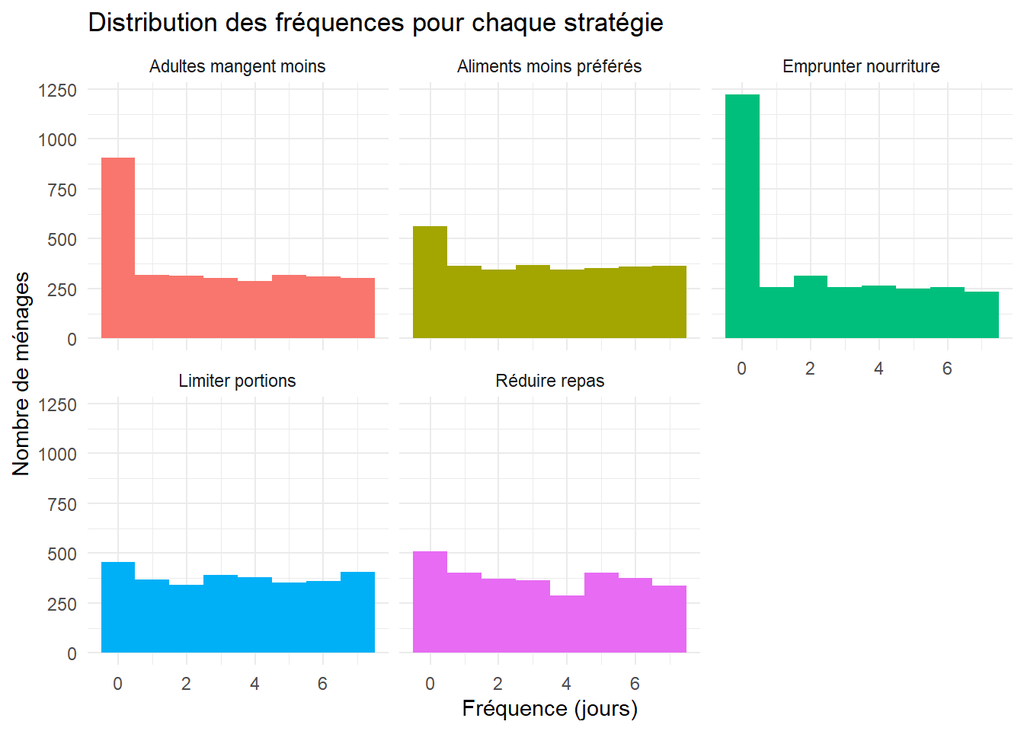

**Interprétation des tendances** Les ménages adoptent des stratégies alimentaires variées, mais certaines semblent plus communes que d’autres. Une fréquence élevée de 0 jours pour certaines stratégies peut indiquer des contraintes économiques ou un manque d’accès. Les stratégies les plus utilisées pourraient être les plus accessibles ou les plus adaptées aux besoins des ménages.

**Implications pour la sécurité alimentaire** Comprendre les comportements alimentaires pour adapter les programmes d’aide. Identification des stratégies essentielles pour mieux cibler les interventions nutritionnelles. Améliorer l’accès aux ressources alimentaires pour encourager une diversité alimentaire et une meilleure résilience.

###### 2.4.1.0.0.4 Calcul de l’indice réduit des stratégies de survie (rCSI)

```
[1] 21
```

```
Table: Poids attribués aux stratégies pour le calcul du rCSI

|strategie               |variable    | poids|
|:-----------------------|:-----------|-----:|
|Aliments moins préférés |food02a_num |     2|
|Emprunter nourriture    |food05a_num |     2|
|Limiter portions        |food06a_num |     3|
|Réduire repas           |food08a_num |     7|
|Adultes mangent moins   |food07a_num |     7|
```

```
   Min. 1st Qu.  Median    Mean 3rd Qu.    Max.    NA's
   0.00   43.00   67.00   64.15   87.00  136.00      15
```

```
Table: Répartition des ménages par niveau de stress alimentaire

|categorie_rcsi |    n| proportion|
|:--------------|----:|----------:|
|Faible         |  183|  5.9843035|
|Moyen-faible   |   47|  1.5369523|
|Moyen-élevé    |  109|  3.5644212|
|Élevé          | 2704| 88.4238064|
|NA             |   15|  0.4905167|
```

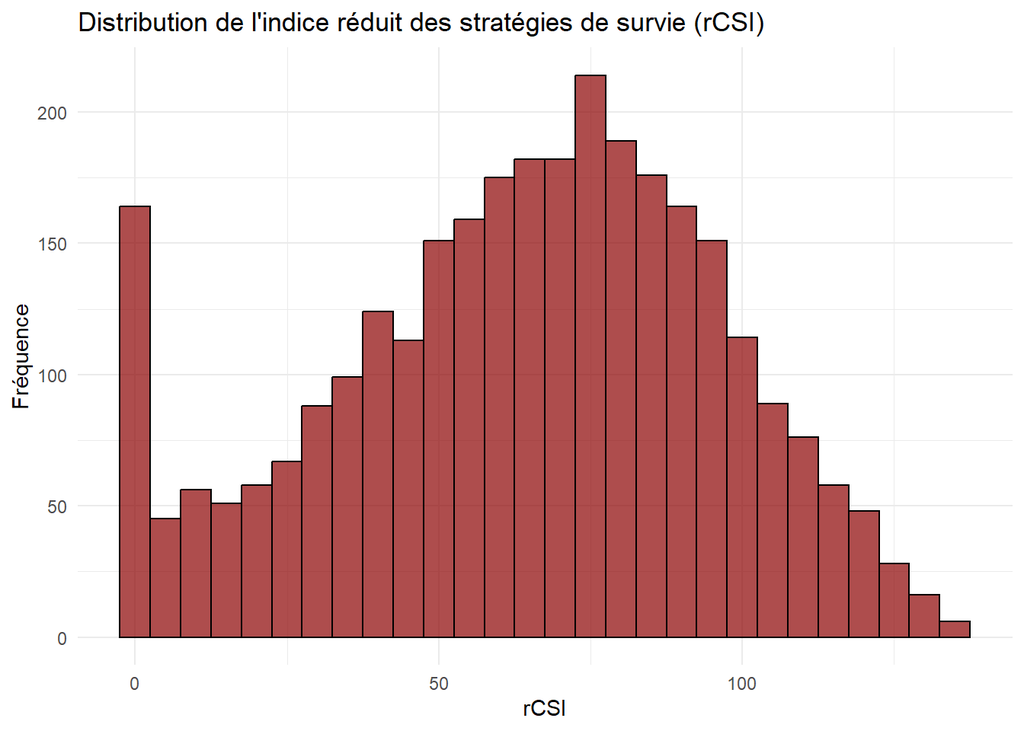

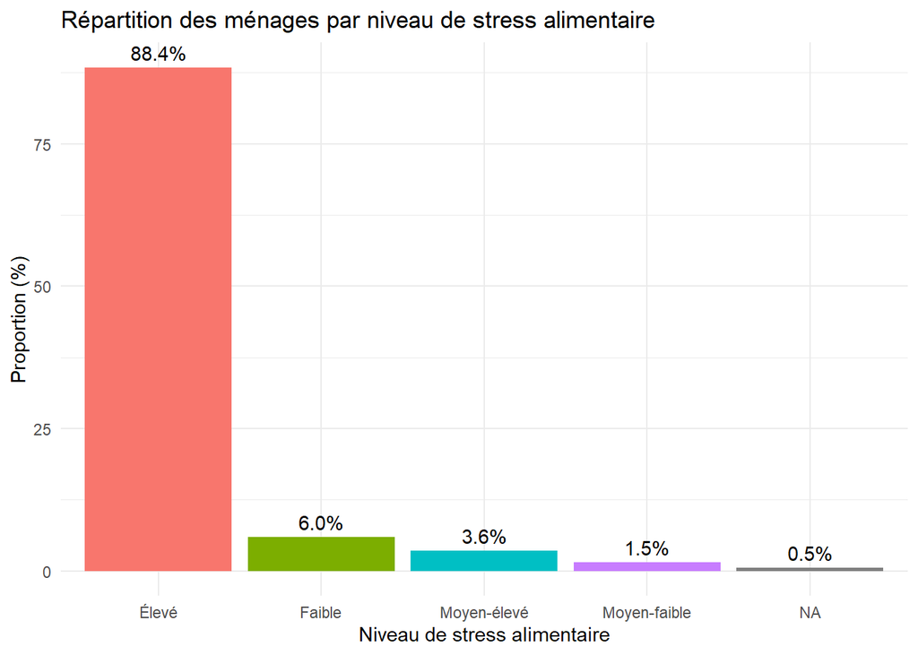

** Distribution de l’indice rCSI**

*Analyse de la distribution*

*Interprétation des tendances*

*Implications pour la sécurité alimentaire*

Les ménages avec un rCSI élevé devraient être prioritaires dans les programmes d’aide alimentaire. Évaluation des ressources : Une analyse approfondie pourrait permettre d’identifier les facteurs influençant les stratégies alimentaires et proposer des solutions durables. Suivi longitudinal : Il serait pertinent d’analyser l’évolution du rCSI au fil du temps pour ajuster les interventions humanitaires et sociales.

**Répartition des ménages par niveau de tress alimentaire**

*Analyse des proportions*

Le stress alimentaire “Élevé” concerne 88.4% des ménages, ce qui indique une situation critique pour la majorité des foyers. Seulement 6.0% des ménages sont dans la catégorie “Faible”, ce qui suggère que très peu de foyers ont un accès stable à la nourriture. Les catégories “Moyen-élevé” (3.6%) et “Moyen-faible” (1.5%) sont peu représentées, montrant que la population est essentiellement divisée entre extrêmes (sécurité vs insécurité alimentaire sévère). Les données manquantes (“NA”) concernent 0.5% des ménages, une proportion négligeable mais qui peut influencer la qualité de l’analyse.

*Interprétation des tendances* Situation préoccupante : Le stress alimentaire élevé chez près de 90% des ménages démontre une insécurité alimentaire généralisée, qui peut être due à des facteurs économiques, climatiques ou géopolitiques. Faible résilience alimentaire : Le manque de ménages en situation intermédiaire (“Moyen-élevé” et “Moyen-faible”) signifie que les ménages peinent à gérer des stratégies d’adaptation et basculent rapidement dans des niveaux de stress élevés. Impact sur la santé et le bien-être : Une insécurité alimentaire prolongée peut entraîner des problèmes nutritionnels, une baisse de productivité et un affaiblissement général de la population.

*Implications socio-économiques* Intervention d’urgence : Des programmes de sécurité alimentaire doivent être renforcés, avec un ciblage précis des foyers les plus vulnérables. Amélioration des chaînes d’approvisionnement : Étudier les causes du stress alimentaire pour adapter les politiques de distribution et de production. Surveillance continue : Il est crucial de suivre l’évolution du stress alimentaire pour adapter les interventions au fil du temps.